# Introduction

Welcome to the 2D Secrets Tower Defense series.

[figure not shown]

In this series, you will build a tower defense game with everything you need to create that kind of game:

1. Towers that automatically target enemies.
2. Enemies that find the shortest path to the player base.
3. Buying and placing towers.
4. Tower upgrades.
5. Map design using tilemaps.
6. Sequences of in-game events like announcing the next enemy wave.
7. Game phases that allow the player to plan and place towers.

I’m Henrique Campos, or Pigdev online, and I’ll be your instructor in this series.

[figure not shown]

## What you’ll learn

You’ll learn plenty of techniques that apply to all sorts of games:

- Pathfinding on a tilemap with the AStar algorithm.
- You’ll design and code UIs to purchase towers and upgrades.
- Sequencing waves of enemies.
- Sequencing game events.
- Using areas to create hit and hurt boxes.
- Firing projectiles (using tween animation).
- Implementing winning and losing conditions.
- Coding an upgrade system to change the towers’ stats.

And more. By the end, I’ll also show you how to build upon this base and add new levels, enemies, and towers.

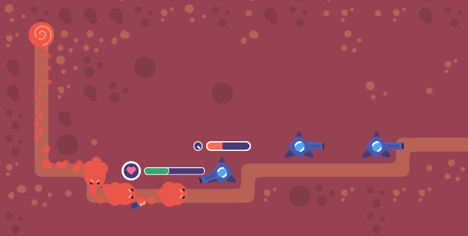

## Prerequisites

This is an intermediate-level series. We assume you’re comfortable reading large GDScript code examples and you know your way around Godot well.

## Participating in the community

I encourage you to discuss the topics presented in the [course community](https://gdquest.mavenseed.com/community). Don’t hesitate to go beyond this series, explore, and share what you find with everyone!

You can also ask a question below any of the following lessons. We will be happy to help.

With that, in the next lesson, you’ll get an overview of what we’ll build together.